# Matrix Computations and the SVD

```python
%load_ext rmagic
import rpy2 as Rpy
```

## Basic vector algebra in R

```python
%%R

print(1:5)                   # a vector of values from 1 to 5
print(c(1,2,3,4,5))          # 'c' is the concatenation function (equivalent to 1:5 here)
print(seq(1, 5))             # seq(m,n) generates vector  ( m, m+1, m+2, ..., n )
print(seq(1, 5, length=5))   # seq(m,n,length=q) generates vector  ( m, m+1s, m+2s, ..., n )  where s = (n-m)/(q-1)  (basically)
print(seq(1, 5, 1))          # seq(m,n,s) generates vector  ( m, m+s, m+2s, ..., p )  where p <= n
print(seq(1, 10, 2))         # seq(m,n,s) generates vector  ( m, m+s, m+2s, ..., p )  where p <= n
```

```
[1] 1 2 3 4 5
[1] 1 2 3 4 5
[1] 1 2 3 4 5
[1] 1 2 3 4 5
[1] 1 2 3 4 5
[1] 1 3 5 7 9
```

```python
%%R

x = 1:5
print(x)
print(t(x))      # 't' is the transpose function; the transpose of a vector is a row vector
print(t(t(x)))   # the transpose of the transpose of a vector is a column vector
```

```
[1] 1 2 3 4 5
     [,1] [,2] [,3] [,4] [,5]
[1,]    1    2    3    4    5
     [,1]
[1,]    1
[2,]    2
[3,]    3
[4,]    4
[5,]    5
```

```python
%%R

x = c( 1+2i , 0-3i )    #  a vector of complex values
print(x)
print(t(x))                    #  the ordinary transpose of x
print(Conj(t(x)))              #  the conjugate transpose of x
```

```
[1] 1+2i 0-3i
     [,1] [,2]
[1,] 1+2i 0-3i
     [,1] [,2]
[1,] 1-2i 0+3i
```

```python
%%R

scalar = function(x,y) { Conj(t(x)) %*% y }

print(scalar( 1:2, 1:2 ))
print(scalar( 1:4, 1:4 ))
```

```
     [,1]
[1,]    5
     [,1]
[1,]   30
```

```python
%%R
norm = function(x) { sqrt(scalar(x,x)) }

print(norm(1:4))
print(norm(1:4)^2)

L2_norm = function(x) { sqrt(scalar(x,x)) }

L1_norm = function(x) { sum(abs(x)) }

print(L1_norm(1:4))
print(sum(1:4))

L_infinity_norm = function(x) { max(abs(x)) }

print(L_infinity_norm(1:4))
```

```
         [,1]
[1,] 5.477226
     [,1]
[1,]   30
[1] 10
[1] 10
[1] 4
```

##### Basic matrix algebra in R

```python
%%R

v = 1:4
print( v )
print( t(v) )

cat("\ndot product\n")
print( t(v) %*% v )
print( crossprod( v, v ) )

cat("\nouter product\n")
print( v %*% t(v) )
print( outer( v, v ) )
print( v %o% v )

cat("\ngeneralized outer products\n")
print( outer( v, v, FUN = "*" ) )
print( outer( v, v, FUN = "+" ) )
```

```
[1] 1 2 3 4
     [,1] [,2] [,3] [,4]
[1,]    1    2    3    4

dot product
     [,1]
[1,]   30
     [,1]
[1,]   30

outer product
     [,1] [,2] [,3] [,4]
[1,]    1    2    3    4
[2,]    2    4    6    8
[3,]    3    6    9   12
[4,]    4    8   12   16
     [,1] [,2] [,3] [,4]
[1,]    1    2    3    4
[2,]    2    4    6    8
[3,]    3    6    9   12
[4,]    4    8   12   16
     [,1] [,2] [,3] [,4]
[1,]    1    2    3    4
[2,]    2    4    6    8
[3,]    3    6    9   12
[4,]    4    8   12   16

generalized outer products
     [,1] [,2] [,3] [,4]
[1,]    1    2    3    4
[2,]    2    4    6    8
[3,]    3    6    9   12
[4,]    4    8   12   16
     [,1] [,2] [,3] [,4]
[1,]    2    3    4    5
[2,]    3    4    5    6
[3,]    4    5    6    7
[4,]    5    6    7    8
```

```python
%%R

print( c( 1:4, 1:4 ) )    # sequence concatenation

print( rbind( 1:4, 1:4 ) )   # row concatenation

print( cbind( 1:4, 1:4 ) )   # column concatenation
```

```
[1] 1 2 3 4 1 2 3 4
     [,1] [,2] [,3] [,4]
[1,]    1    2    3    4
[2,]    1    2    3    4
     [,1] [,2]
[1,]    1    1
[2,]    2    2
[3,]    3    3
[4,]    4    4
```

### Matrix Constructors, and Matrix Slices

```python
%%R

n = 3
p = 5

X <- matrix( 1:(n*p), nr=n, nc=p)
print(X)

Y <- matrix( 1:(n*p), nr=n, nc=p, byrow=TRUE )
print(Y)

print( is.matrix(X) )

print( X[3,5] )
print( X[1:3,5] )
print( X[1:3,] )
print( X[1:3,1:5] )
```

```
     [,1] [,2] [,3] [,4] [,5]
[1,]    1    4    7   10   13
[2,]    2    5    8   11   14
[3,]    3    6    9   12   15
     [,1] [,2] [,3] [,4] [,5]
[1,]    1    2    3    4    5
[2,]    6    7    8    9   10
[3,]   11   12   13   14   15
[1] TRUE
[1] 15
[1] 13 14 15
     [,1] [,2] [,3] [,4] [,5]
[1,]    1    4    7   10   13
[2,]    2    5    8   11   14
[3,]    3    6    9   12   15
     [,1] [,2] [,3] [,4] [,5]
[1,]    1    4    7   10   13
[2,]    2    5    8   11   14
[3,]    3    6    9   12   15
```

### Basic Matrix operators

```python
%%R

cat("\ntranspose of X\n"); print( t(X) )

cat("\nX^T * X\n"); XTX = X %*% t(X); print(XTX)

cat("\ndiagonal of X^T * X\n"); print(diag(XTX))

cat("\ndeterminant of X^T * X\n"); print(det(XTX))

cat("\nidentity matrix\n"); Id = diag(rep(1,3)); print(Id)
```

```
transpose of X
     [,1] [,2] [,3]
[1,]    1    2    3
[2,]    4    5    6
[3,]    7    8    9
[4,]   10   11   12
[5,]   13   14   15

X^T * X
     [,1] [,2] [,3]
[1,]  335  370  405
[2,]  370  410  450
[3,]  405  450  495

diagonal of X^T * X
[1] 335 410 495

determinant of X^T * X
[1] 0

identity matrix
     [,1] [,2] [,3]
[1,]    1    0    0
[2,]    0    1    0
[3,]    0    0    1
```

### More interesting matrix operators

```python
%%R

Z = matrix(0, 3, 3)  # 3x3 matrix of zeros
diag(Z) = 1   # set the diagonal to 1!
print(Z)

cat("\ninverse of I + X^T * X\n"); print(solve(XTX + Id))

cat("\neigenstructure of X^T * X\n"); print(eigen(XTX))

cat("\nFFT of X^T * X\n"); print(fft(XTX))
```

```
     [,1] [,2] [,3]
[1,]    1    0    0
[2,]    0    1    0
[3,]    0    0    1

inverse of I + X^T * X
            [,1]       [,2]        [,3]
[1,]  0.34407511 -0.3222532  0.01141842
[2,] -0.32225324  0.6675971 -0.34255265
[3,]  0.01141842 -0.3425527  0.30347628

eigenstructure of X^T * X
$values
[1]  1.237819e+03  2.181256e+00 -3.937210e-14

$vectors
           [,1]        [,2]       [,3]
[1,] -0.5192726 -0.75079244  0.4082483
[2,] -0.5755207 -0.04592639 -0.8164966
[3,] -0.6317688  0.65893966  0.4082483


FFT of X^T * X
              [,1]              [,2]              [,3]
[1,] 3690+  0.000i -180.0+103.92305i -180.0-103.92305i
[2,] -180+103.923i    7.5- 12.99038i   15.0-  0.00000i
[3,] -180-103.923i   15.0+  0.00000i    7.5+ 12.99038i
```

# Positive Definite and Positive Semidefinite Matrices

**"Positive semidefinite"**: all eigenvalues of $A$ are non-negative real values.

**"Positive definite"**: all eigenvalues of $A$ are positive real values.

The determinant of a matrix $A$ is the product of its eigenvalues.

## Any real matrix $A$ of the form $A = X' X$ is real symmetric and positive semidefinite.

```python
%%R

X = matrix(runif(5*4), 5,4)
Y = matrix(runif(5*4), 5,4)
Z = X + 1i * Y
A = Conj(t(Z)) %*% Z
print(A)

print( eigen(A)$values )

cat(paste("\nproduct of A's eigenvalues = ",( prod(eigen(A)$values) ), "\n"))

cat(paste("\ndet(A) = ", det(A), "\n"))
```

```
                   [,1]               [,2]               [,3]
[1,] 4.582321+0.000000i 3.968810-0.017679i 3.287710-0.194024i
[2,] 3.968810+0.017679i 4.310908+0.000000i 3.087814-0.775808i
[3,] 3.287710+0.194024i 3.087814+0.775808i 3.640843+0.000000i
[4,] 4.104088-0.182076i 3.959355+0.248152i 3.498231-0.230642i
                   [,4]
[1,] 4.104088+0.182076i
[2,] 3.959355-0.248152i
[3,] 3.498231+0.230642i
[4,] 4.638741+0.000000i
[1] 15.3631774  1.1585731  0.4910497  0.1600131

product of A's eigenvalues =  1.39857451172617
Error in determinant.matrix(x, logarithm = TRUE, ...) :
  'determinant' not currently defined for complex matrices
```

## Covariance matrices are real symmetric, and positive semidefinite

```python
%%R

cat("\nThe covariance matrix is symmetric:\n")
print( cov(X) == t(cov(X)) )

cat(paste("\ndeterminant of covariance matrix =", det( cov(X) ) ))
```

```
The covariance matrix is symmetric:
     [,1] [,2] [,3] [,4]
[1,] TRUE TRUE TRUE TRUE
[2,] TRUE TRUE TRUE TRUE
[3,] TRUE TRUE TRUE TRUE
[4,] TRUE TRUE TRUE TRUE

determinant of covariance matrix = 3.62591987524215e-07
```

# Eigendecomposition of a real symmetric matrix

## We can decompose real symmetric matrices into eigenvalues and eigenvectors

```python
%%R

A = matrix(c(1.4, 1.3, 1.3, 0.7), 2,2)

Aeigen = eigen(A)
Q = Aeigen$vectors
L = diag(Aeigen$values)

cat( "\nA matrix:\n" )
print( A )

cat( "\nEigendecomposition of A:\n" )

cat("\nQ:\n"); print( Q )
cat("\nL:\n"); print( L )

cat( "\nA  ==  Q * L * t(Q):\n" )
print( A )
print( Q %*% L %*% t(Q) )
```

```
A matrix:
     [,1] [,2]
[1,]  1.4  1.3
[2,]  1.3  0.7

Eigendecomposition of A:

Q:
           [,1]       [,2]
[1,] -0.7937170  0.6082872
[2,] -0.6082872 -0.7937170

L:
         [,1]       [,2]
[1,] 2.396291  0.0000000
[2,] 0.000000 -0.2962912

A  ==  Q * L * t(Q):
     [,1] [,2]
[1,]  1.4  1.3
[2,]  1.3  0.7
     [,1] [,2]
[1,]  1.4  1.3
[2,]  1.3  0.7
```

### Decomposition of the Covariance Matrix of the Iris data

```python
%%R

A = cov(data.matrix( iris[,1:4] ) )

Aeigen = eigen(A)
Q = Aeigen$vectors
L = diag(Aeigen$values)

cat( "\nA matrix:\n" )
print( A )

cat( "\nEigendecomposition of A:\n" )

cat("\nQ:\n"); print( Q )
cat("\nL:\n"); print( L )

cat( "\nA  ==  Q * L * t(Q):\n" )
print( A )
print( Q %*% L %*% t(Q) )
```

```
A matrix:
             Sepal.Length Sepal.Width Petal.Length Petal.Width
Sepal.Length    0.6856935  -0.0424340    1.2743154   0.5162707
Sepal.Width    -0.0424340   0.1899794   -0.3296564  -0.1216394
Petal.Length    1.2743154  -0.3296564    3.1162779   1.2956094
Petal.Width     0.5162707  -0.1216394    1.2956094   0.5810063

Eigendecomposition of A:

Q:
            [,1]        [,2]        [,3]       [,4]
[1,]  0.36138659 -0.65658877 -0.58202985  0.3154872
[2,] -0.08452251 -0.73016143  0.59791083 -0.3197231
[3,]  0.85667061  0.17337266  0.07623608 -0.4798390
[4,]  0.35828920  0.07548102  0.54583143  0.7536574

L:
         [,1]      [,2]      [,3]       [,4]
[1,] 4.228242 0.0000000 0.0000000 0.00000000
[2,] 0.000000 0.2426707 0.0000000 0.00000000
[3,] 0.000000 0.0000000 0.0782095 0.00000000
[4,] 0.000000 0.0000000 0.0000000 0.02383509

A  ==  Q * L * t(Q):
             Sepal.Length Sepal.Width Petal.Length Petal.Width
Sepal.Length    0.6856935  -0.0424340    1.2743154   0.5162707
Sepal.Width    -0.0424340   0.1899794   -0.3296564  -0.1216394
Petal.Length    1.2743154  -0.3296564    3.1162779   1.2956094
Petal.Width     0.5162707  -0.1216394    1.2956094   0.5810063
           [,1]       [,2]       [,3]       [,4]
[1,]  0.6856935 -0.0424340  1.2743154  0.5162707
[2,] -0.0424340  0.1899794 -0.3296564 -0.1216394
[3,]  1.2743154 -0.3296564  3.1162779  1.2956094
[4,]  0.5162707 -0.1216394  1.2956094  0.5810063
```

## The incredible "scree plot"

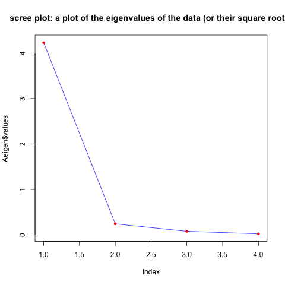

```python
%%R

plot( Aeigen$values, col="blue", type="l",    # plot lines through the points
     main="scree plot: a plot of the eigenvalues of the data (or their square roots)" )

points( Aeigen$values, pch=20, col="red" )   # add actual "points" to the plot
```

Notice that the first eigenvalue (which is largest) is much larger than the others. This is typical.

# Interpreting the Eigendecomposition Geometrically

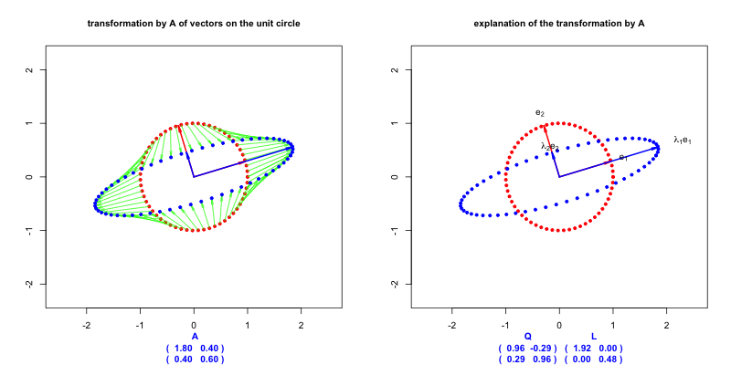

```python
%%R -h 400 -w 800

LinearTransformPlot = function (A = matrix(c(9/5,2/5,2/5,3/5),2,2), n = 60) {

#   The 2x2 matrix A should be real and symmetric;
#   it is used to map the unit circle (with a total of n points) to an ellipse;
#   the axes of the ellipse are the eigenvectors of A, stretched by its eigenvalues.

   t = seq(0, 2*pi, length = n)

   x = rbind( cos(t) , sin(t) )   #   x  =  a sequence of n vectors (points on the unit circle)
   Ax = A %*% x;                  #  Ax  =  the result of transforming all vectors in x by A

   x1 = x[1,];
   x2 = x[2,];

   Ax1 = Ax[1,];
   Ax2 = Ax[2,];

   A_eigen = eigen(A)
   lambda = A_eigen$values
   L      = diag(A_eigen$values)
   Q      = A_eigen$vectors

   e1 = Q[,1]  #  1st eigenvector
   e2 = Q[,2]  #  2nd eigenvector

   if (max(e1) <= 0) {
      e1 = -e1; Q[,1] = -Q[,1];  # if e is an eigenvector, then -e is an eigenvector too:
      e2 = -e2; Q[,2] = -Q[,2];  # so we choose e1 so that it has at least one positive entry.
   }

   xmax = max( lambda[1], 1.0 ) * 1.33
   ymax = max( lambda[2], 1.0 ) * 1.33

   QL = Q %*% L
   Id = diag(c(1,1))
   zeroes = c(0,0)

   row_format = " ( % 4.2f  % 4.2f ) "
   A_format = paste(" A\n ", row_format, "\n", row_format)
   A_values = sprintf( A_format, A[1,1],A[1,2], A[2,1],A[2,2] )
   QL_format = paste(" Q                       L\n ", row_format, row_format, "\n", row_format, row_format)
   QL_values = sprintf(QL_format, Q[1,1],Q[1,2],L[1,1],L[1,2], Q[2,1],Q[2,2],L[2,1],L[2,2])

   opar = par(mfrow=c(1,2), cex=0.85, cex.main=1.0, cex.sub=1.0, font.sub=2)  # make a 1x2 set of plots in one figure

   plot( x1, x2, col="red", pch=20,
      asp=1.0, xlim = c(-xmax, xmax), ylim = c(-ymax,ymax), xlab="", ylab="",
      main="transformation by A of vectors on the unit circle", sub=A_values, col.sub="blue" )
   arrows( x1, x2, Ax1, Ax2, col="green", lwd=1.0, angle=8, length=0.1 )
   arrows( zeroes, zeroes,  Q[1,],  Q[2,], col="red",  lwd=2, angle=8, length=0.1 )
   arrows( zeroes, zeroes, QL[1,], QL[2,], col="blue", lwd=2, angle=8, length=0.1 )
   points( Ax1, Ax2, col="blue", pch=20)

   plot( x1, x2, col="red", pch=20,
      asp=1.0, xlim = c(-xmax, xmax), ylim = c(-ymax,ymax), xlab="", ylab="",
      main="explanation of the transformation by A", sub=QL_values, col.sub="blue" )
   points( Ax1, Ax2, col="blue", pch=20)
   arrows( zeroes, zeroes,  Q[1,],  Q[2,], col="red",  lwd=2, angle=8, length=0.1 )
   arrows( zeroes, zeroes, QL[1,], QL[2,], col="blue", lwd=2, angle=8, length=0.1 )
   text( 1.25 *  Q[1,], 1.25 *  Q[2,], c(expression(e[1]), expression(e[2])) )
   text( 1.25 * QL[1,], 1.25 * QL[2,], c(expression(lambda[1]*e[1]), expression(lambda[2]*e[2])) )

   par(opar)
}

LinearTransformPlot()
```

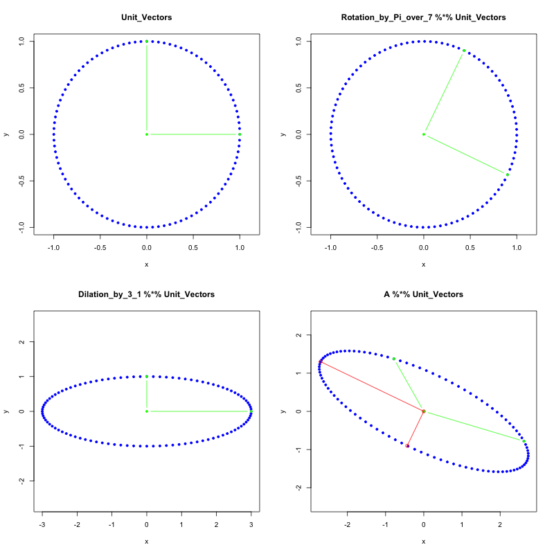

```python
%%R -h 800 -w 800
#----------------------------------------------------------------------------------------
#   Exploring the effect of linear transforms on unit vectors (points on the unit circle)
#----------------------------------------------------------------------------------------

N <- 100
Thetas <- ((0:N) / N) * (2*pi)

Unit_Vectors <- rbind( sin(Thetas),
                       cos(Thetas)  )

Axes <- rbind( c( 0, 0, 1 ),
                     c( 1, 0, 0 ) )

Points <- cbind( Unit_Vectors, Axes )

plotpoints <- function(Points, Axes) {
   plot(t(Points), main=paste(deparse(substitute(Points))), xlab="x", ylab="y", pch=20,
               asp=1, col="blue", type="b" )  # asp=1 gets fixed aspect ratio = 1
   points(t(Axes), col="green", type="b", pch=20)
}


opar <- par(mfrow=c(2,2))

plotpoints(Unit_Vectors, Axes)
#----------------------------------------------------------------------------------------
#   What a rotation matrix does
#----------------------------------------------------------------------------------------

t <- pi/7
Rotation_by_Pi_over_7 <- matrix(c( cos(t), -sin(t), sin(t), cos(t) ), 2, 2)
Rotation_by_Pi_over_7

plotpoints(Rotation_by_Pi_over_7 %*% Unit_Vectors, Rotation_by_Pi_over_7 %*% Axes)

eigen(Rotation_by_Pi_over_7)

#----------------------------------------------------------------------------------------
#   What a dilation matrix does
#----------------------------------------------------------------------------------------

Dilation_by_3_1 <- diag(c( 3, 1 ))
Dilation_by_3_1

plotpoints(Dilation_by_3_1 %*% Unit_Vectors, Dilation_by_3_1 %*% Axes)

eigen(Dilation_by_3_1)

#----------------------------------------------------------------------------------------
#   What the combination of a rotation and dilation does
#----------------------------------------------------------------------------------------

A <- Rotation_by_Pi_over_7 %*% Dilation_by_3_1 %*% t(Rotation_by_Pi_over_7)
A

plotpoints(A %*% Unit_Vectors, A %*% Axes)

#----------------------------------------------------------------------------------------
#   How this relates to eigenvalues and eigenvectors
#----------------------------------------------------------------------------------------

eig <- eigen(A)
eig

eig$values[1]

(A %*% eig$vectors[,1]) / eig$vectors[,1]

lambda1 = eig$values[1]
lambda2 = eig$values[2]

e1 = eig$vectors[,1]
e2 = eig$vectors[,2]

points( matrix( c( lambda1*e1,  c(0,0), lambda2*e2 ), 3, 2, byrow=TRUE ), type="o", col="red" )

par(opar)
```

# The Singular Value Decomposition (SVD)

Theorem: If $A$ is an arbitrary (real or complex) $n \times p$ matrix where $n > p$, there is an SVD matrix decomposition $A = U S V'$ where $U$ is an $n \times n$ unitary matrix, $V$ is a $p \times p$ unitary matrix, and $S$ is an $n \times p$ matrix whose nonzero entries arise only on its diagonal.

```python
%%R

A = matrix(c(1.4, 1.3, 0.1, 0.7), 2,2)

Asvd = svd(A)
U = Asvd$u
S = diag(Asvd$d)
V = Asvd$v

cat( "\nA matrix:\n" )
print( A )

cat( "\nSVD of A (decomposition into U, S, V):\n" )

cat("\nU:\n"); print( U )
cat("\nS:\n"); print( S )
cat("\nV:\n"); print( V )

cat( "\nA  ==  U * S * t(V):\n" )
print( A )
print( U %*% S %*% t(V) )
```

```
A matrix:
     [,1] [,2]
[1,]  1.4  0.1
[2,]  1.3  0.7

SVD of A (decomposition into U, S, V):

U:
           [,1]       [,2]
[1,] -0.6872154 -0.7264537
[2,] -0.7264537  0.6872154

S:
         [,1]      [,2]
[1,] 1.991962 0.0000000
[2,] 0.000000 0.4267149

V:
           [,1]       [,2]
[1,] -0.9570920 -0.2897841
[2,] -0.2897841  0.9570920

A  ==  U * S * t(V):
     [,1] [,2]
[1,]  1.4  0.1
[2,]  1.3  0.7
     [,1] [,2]
[1,]  1.4  0.1
[2,]  1.3  0.7
```

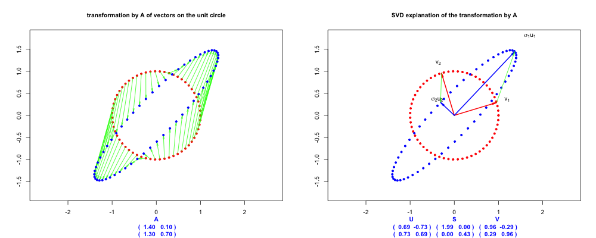

```python
%%R -h 400 -w 1000

LinearTransformPlot = function (A = matrix(c(1.4, 1.3, 0.1, 0.7), 2,2), n = 60) {

#   The 2x2 matrix A should be real and symmetric;
#   it is used to map the unit circle (with a total of n points) to an ellipse;
#   the axes of the ellipse are the eigenvectors of A, stretched by its eigenvalues.

   t = seq(0, 2*pi, length=n)
   x1 = cos(t)
   x2 = sin(t)
   x = rbind( x1,  x2 )     #  x  = the unit circle  (= 2 x n matrix of (cos(t),sin(t)) vectors)

   Ax = A %*% x             #  Ax = the transformation by A of every vector in x
   Ax1 = Ax[1,]
   Ax2 = Ax[2,]

   USV = svd(A)
   sigma = USV$d
   S = diag(sigma)
   U = USV$u
   V = t(USV$v)

   u1 = U[,1]  # 1st left eigenvector
   u2 = U[,2]  # 2nd left eigenvector
   v1 = V[,1]  # 1st right eigenvector
   v2 = V[,2]  # 2nd right eigenvector
   if (max(u1) <= 0) {
      u1 = -u1; U[,1] = -U[,1];  # if u1 is an eigenvector, then -u2 is an eigenvector too:
      v1 = -v1; V[,1] = -V[,1];  # so choose u1 so that it has at least one positive entry.
   }
   if (max(u2) <= 0) {
      u2 = -u2; U[,2] = -U[,2];  # if u2 is an eigenvector, then -u2 is an eigenvector too:
      v2 = -v2; V[,2] = -V[,2];  # so choose u2 so that it has at least one positive entry.
   }

   U_sigma = U %*% diag(sigma)
   xmax = max( sigma[1], 1.0 ) * 1.33
   ymax = max( sigma[2], 1.0 ) * 1.33
   zeroes = c(0, 0)

   row_format = " ( % 4.2f  % 4.2f ) "
   A_format = paste("A\n ", row_format, "\n", row_format)
   A_values = sprintf( A_format, A[1,1],A[1,2], A[2,1],A[2,2] )
   USV_format = paste("U                       S                       V\n ",
       row_format, row_format, row_format, "\n", row_format, row_format, row_format)
   USV_values = sprintf(USV_format, U[1,1],U[1,2],S[1,1],S[1,2],V[1,1],V[1,2], U[2,1],U[2,2],S[2,1],S[2,2],V[2,1],V[2,2])

   opar = par(mfrow=c(1,2), cex=0.85, cex.main=1.0, cex.sub=1.0, font.sub=2 )   #  plot 2 figures in a 1x2 arrangement

   plot( x1, x2, pch=20, col="red",
      asp=1.0, xlim = c(-xmax, xmax), ylim = c(-ymax,ymax), xlab="", ylab="",
      main = "transformation by A of vectors on the unit circle",
      sub  = A_values, col.sub="blue" )
   arrows( x1, x2, Ax1, Ax2, col="green", lwd=1, angle=8, length=0.1 )
   points( Ax1, Ax2, pch=20, col="blue" )

   plot( x1, x2, pch=20, col="red",
      asp=1.0, xlim = c(-xmax, xmax), ylim = c(-ymax,ymax), xlab="", ylab="",
      main = "SVD explanation of the transformation by A",
      sub  = USV_values, col.sub="blue" )
   points( Ax1, Ax2, pch=20, col="blue" )
   arrows( zeroes, zeroes,       V[1,],       V[2,], col="red",   lwd=2, angle=8, length=0.1 )
   arrows( zeroes, zeroes, U_sigma[1,], U_sigma[2,], col="blue",  lwd=2, angle=8, length=0.1 )
   arrows( V[1,],  V[2,],  U_sigma[1,], U_sigma[2,], col="green", lwd=1, angle=8, length=0.1 )
   text( 1.25 *       V[1,],       1.25 * V[2,], c(expression(v[1]),          expression(v[2])         ) )
   text( 1.25 * U_sigma[1,], 1.25 * U_sigma[2,], c(expression(sigma[1]*u[1]), expression(sigma[2]*u[2])) )

   par(opar)
}

LinearTransformPlot()
```